# R Markdown

Антон Антонов

# knitr

- За обработку кода на R отвечает пакет `knitr`
- Он может быть использован отдельно от R Markdown
- Изначальный фокус `knitr` – pdf (LaTeX + R)

# Chunk options

- Существуют глобальные настройки `knitr`
- Каждый чанк может иметь локальные настройки, переопределяющие глобальные
- Локальные настройки указываются через запятую
- Все возможные опции приведены на http://yihui.name/knitr/options/

# Основные опции

- `echo` (default: `TRUE`) – отображать ли исходный код чанка?
- `eval` (default: `TRUE`) – исполнять ли код чанка?
- `include` (default: `TRUE`) – отображать ли результат исполнения чанка?
- `error` (default: `FALSE`) – добавлять ли в документ текст ошибок?
- `message` (default: `TRUE`) – добавлять ли в документ текст сообщений?
- `warning` (default: `TRUE`) – добавлять ли в документ текст предупреждений?

# Основные опции

- `comment` (default: `'##'`) – какой префикс добавлять перед каждой строкой вывода результатов?
- `results` (default: `'markup'`) – каким образом выводить результаты исполнения?
- `highlight` (default: `TRUE`) – подсвечивать ли синтаксис кода?
- `tidy` (default: `FALSE`) – отформатировать ли код (отступы, пробелы)?

# Графики

- `fig.height`, `fig.width` – размеры изображения (в дюймах)
- `fig.align` (default: `'center'`) – расположение графика на странице
- `fig.cap` (default: `NULL`) – строка с подписью к графику

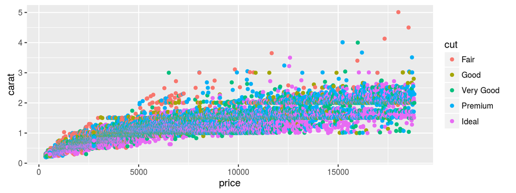

# Кеширование чанков

- Некоторые чанки могут содержать длинные вычисления
- Для таких чанков нужно выставить `cache=TRUE`
- Кеш срабатывает в том случае, если содержимое кода внутри чанка не изменилось
- Важно: если чанки взаимозависимы, нужно помнить о кеше!
- В этих случаях поможет опция `dependson`
- Важно: некоторые алгоритмы используют генераторы случайных чисел!

# Метки чанков

- В фигурных скобках между “r” и опциями чанка может находиться метка чанка
- Чанки могут обращаться друг к другу по меткам

````
```{r chunk1, echo=TRUE, results='hide'}
cos(2*pi)
```
````

````
```{r chunk2, echo=FALSE, ref.label='chunk1'}
```
````

```r
cos(2*pi)
```

```
## [1] 1
```

# Глобальные опции

- Задаются, как правило, в начале документа
- `knitr::opts_chunk$set(echo=FALSE, fig.width=5, fig.height=5)`
- Этот вызов удобно поместить в отдельный чанк с опцией `include=FALSE`